[figure not shown]

# Recommender System Using Python

## Analytics for BI Project

### RUID: 196000794

## Contents

1. What is Recommender System?
2. Types of recommendation engines
3. Dataset
4. Exploratory Data Analysis
5. Item based recommender system
6. Recommendation output

# 1. What is Recommender System?

A recommender system is a simple algorithm whose aim is to provide the most relevant information to a user by discovering patterns in a dataset. The algorithm rates the items and shows the user the items that they would rate highly.

An example of recommendation in action is when you visit Amazon and you notice that some items are being recommended to you or when Netflix recommends certain movies to you. They are also used by Music streaming applications such as Spotify and Deezer to recommend music that you might like.

# 2. Types of recommendation engines

The most common types of recommendation systems are:

1) Collaborative filtering recommender systems

2) Content based filtering recommender systems

## 1) Collaborative filtering recommender systems:

In collaborative filtering the behavior of a group of users is used to make recommendations to other users. Recommendation is based on the preference of other users. A simple example would be recommending a movie to a user based on the fact that their friend liked the movie.

There are two types of collaborative models:

```
  1) Memory-based methods
  2) Model-based methods
```

### 1.1) Memory-based methods:

Advantages of memory-based techniques:

1. They are simple to implement
2. The resulting recommendations are often easy to explain

They are divided into two:

a) User-based collaborative filtering: In this model products are recommended to a user based on the fact that the products have been liked by users similar to the other user. For example if User1 and User2 like the same movies and a new movie comes out that User1 likes then we can recommend that movie to User2 because User1 and User2 seem to like the same movies.

b) Item-based collaborative filtering: These systems identify similar items based on users’ previous ratings. For example if users A,B and C gave a 5 star rating to books X and Y then when a user D buys book Y they also get a recommendation to purchase book X because the system identifies book X and Y as similar based on the ratings of users A,B and C.

### 1.2) Model-based methods:

Model-based methods are based on matrix factorization and are better at dealing with sparsity. They are developed using data mining, machine learning algorithms to predict users’ rating of unrated items. In this approach techniques such as dimensionality reduction are used to improve the accuracy. Examples of such model-based methods include decision trees, rule-based models, Bayesian methods and latent factor models.

## 2) Content based systems:

Content based systems use meta data such as genre, producer, actor, musician to recommend items say movies or music. Such a recommendation would be for instance recommending movie that featured particular actor because someone watched and liked his other movies. Similarly you can get music recommendations from certain artists because you liked their music. Content based systems are based on the idea that if you liked a certain item you are most likely to like something that is similar to it.

# 3. Approach

## Here is a very simple illustration of how recommender systems work in the context of an e-commerce site.

Two users buy the same items A and B from an ecommerce store.

When this happens the similarity index of these two users is computed.

Depending on the score the system can recommend item C to the other user because it detects that those two users are similar in terms of the items they purchase.

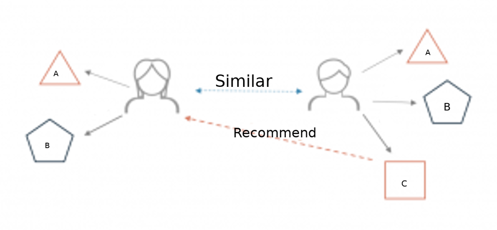

# 4. Dataset

We have used the MovieLens Dataset.

We are using 3 files:

1. Users dataset
2. Movie ratings
3. Movies List

These files contain 1,000,209 anonymous ratings of approximately 3,900 movies made by 6,040 MovieLens users who joined MovieLens in 2000.

1. USERS FILE DESCRIPTION

================================================================================

User information is in the file "users.csv" and is in the following format:

UserID::Gender::Age::Occupation::Zip-code

- Gender is denoted by a "M" for male and "F" for female
- Age is chosen from the following ranges:
  - 1: "Under 18"
  - 18: "18-24"
  - 25: "25-34"
  - 35: "35-44"
  - 45: "45-49"
  - 50: "50-55"
  - 56: "56+"
- Occupation is chosen from the following choices:
  - 0: "other" or not specified
  - 1: "academic/educator"
  - 2: "artist"
  - 3: "clerical/admin"
  - 4: "college/grad student"
  - 5: "customer service"
  - 6: "doctor/health care"
  - 7: "executive/managerial"
  - 8: "farmer"
  - 9: "homemaker"
  - 10: "K-12 student"
  - 11: "lawyer"
  - 12: "programmer"
  - 13: "retired"
  - 14: "sales/marketing"
  - 15: "scientist"
  - 16: "self-employed"
  - 17: "technician/engineer"
  - 18: "tradesman/craftsman"
  - 19: "unemployed"
  - 20: "writer"
1. RATINGS FILE DESCRIPTION

================================================================================

All ratings are contained in the file "ratings.csv" and are in the following format:

UserID::MovieID::Rating::Timestamp

- UserIDs range between 1 and 6040
- MovieIDs range between 1 and 3952
- Ratings are made on a 5-star scale (whole-star ratings only)
- Timestamp is represented in seconds since the epoch as returned by time(2)
- Each user has at least 20 ratings
1. MOVIES FILE DESCRIPTION

================================================================================

Movie information is in the file "movies.csv" and is in the following format:

MovieID::Title::Genres

- Titles are identical to titles provided by the IMDB (including year of release)
- Genres are pipe-separated and are selected from the following genres:
  - Action
  - Adventure
  - Animation
  - Children's
  - Comedy
  - Crime
  - Documentary
  - Drama
  - Fantasy
  - Film-Noir
  - Horror
  - Musical
  - Mystery
  - Romance
  - Sci-Fi
  - Thriller
  - War
  - Western

## 4.1 Importing required Python libraries

```python
#import pandas and numpy

import pandas as pd
import numpy as np
import warnings
warnings.filterwarnings('ignore')
```

## 4.2 Loading Dataset

```python
# read Users data

Users = pd.read_csv('C:\\Users\\Deepal\\Desktop\\ABI Project\\Users.csv')
Users.head(10)
```

|  | UserID | Gender | Age | Occupation | Zip-code |
| --- | --- | --- | --- | --- | --- |
| 0 | 1 | F | 1 | 10 | 48067 |
| 1 | 2 | M | 56 | 16 | 70072 |
| 2 | 3 | M | 25 | 15 | 55117 |
| 3 | 4 | M | 45 | 7 | 2460 |
| 4 | 5 | M | 25 | 20 | 55455 |
| 5 | 6 | F | 50 | 9 | 55117 |
| 6 | 7 | M | 35 | 1 | 6810 |
| 7 | 8 | M | 25 | 12 | 11413 |
| 8 | 9 | M | 25 | 17 | 61614 |
| 9 | 10 | F | 35 | 1 | 95370 |

```python
# read Movie Ratings data

MovieRatings = pd.read_csv('C:\\Users\\Deepal\\Desktop\\ABI Project\\Movie ratings.csv')
MovieRatings.head(10)
```

|  | UserID | MovieID | Ratings | Timestamp |
| --- | --- | --- | --- | --- |
| 0 | 1 | 1 | 5 | 978824268 |
| 1 | 1 | 48 | 5 | 978824351 |
| 2 | 1 | 150 | 5 | 978301777 |
| 3 | 1 | 260 | 4 | 978300760 |
| 4 | 1 | 527 | 5 | 978824195 |
| 5 | 1 | 531 | 4 | 978302149 |
| 6 | 1 | 588 | 4 | 978824268 |
| 7 | 1 | 594 | 4 | 978302268 |
| 8 | 1 | 595 | 5 | 978824268 |
| 9 | 1 | 608 | 4 | 978301398 |

```python
# read Movie List data

MovieList = pd.read_csv('C:\\Users\\Deepal\\Desktop\\ABI Project\\Movies List.csv', encoding='latin-1')
MovieList.head(10)
```

|  | MovieID | MovieName | Genres |
| --- | --- | --- | --- |
| 0 | 1 | Toy Story (1995) | Animation Children's Comedy |
| 1 | 2 | Jumanji (1995) | Adventure Children's Fantasy |
| 2 | 3 | Grumpier Old Men (1995) | Comedy Romance |
| 3 | 4 | Waiting to Exhale (1995) | Comedy Drama |
| 4 | 5 | Father of the Bride Part II (1995) | Comedy |
| 5 | 6 | Heat (1995) | Action Crime Thriller |
| 6 | 7 | Sabrina (1995) | Comedy Romance |
| 7 | 8 | Tom and Huck (1995) | Adventure Children's |
| 8 | 9 | Sudden Death (1995) | Action |
| 9 | 10 | GoldenEye (1995) | Action Adventure Thriller |

## 4.3 Merge two dataset

Since the MovieID columns are the same we can merge these datasets on this column.

```python
# merge two dataset

Movie_Ratings = pd.merge(MovieRatings, MovieList, on='MovieID')
Movie_Ratings.head(10)
```

|  | UserID | MovieID | Ratings | Timestamp | MovieName | Genres |
| --- | --- | --- | --- | --- | --- | --- |
| 0 | 1 | 1 | 5 | 978824268 | Toy Story (1995) | Animation Children's Comedy |
| 1 | 6 | 1 | 4 | 978237008 | Toy Story (1995) | Animation Children's Comedy |
| 2 | 8 | 1 | 4 | 978233496 | Toy Story (1995) | Animation Children's Comedy |
| 3 | 9 | 1 | 5 | 978225952 | Toy Story (1995) | Animation Children's Comedy |
| 4 | 10 | 1 | 5 | 978226474 | Toy Story (1995) | Animation Children's Comedy |
| 5 | 18 | 1 | 4 | 978154768 | Toy Story (1995) | Animation Children's Comedy |
| 6 | 19 | 1 | 5 | 978555994 | Toy Story (1995) | Animation Children's Comedy |
| 7 | 21 | 1 | 3 | 978139347 | Toy Story (1995) | Animation Children's Comedy |
| 8 | 23 | 1 | 4 | 978463614 | Toy Story (1995) | Animation Children's Comedy |
| 9 | 26 | 1 | 3 | 978130703 | Toy Story (1995) | Animation Children's Comedy |

```python
Movie_Ratings.describe()
```

|  | UserID | MovieID | Ratings | Timestamp |
| --- | --- | --- | --- | --- |
| count | 1.000209e+06 | 1.000209e+06 | 1.000209e+06 | 1.000209e+06 |
| mean | 3.024512e+03 | 1.865540e+03 | 3.581564e+00 | 9.722437e+08 |
| std | 1.728413e+03 | 1.096041e+03 | 1.117102e+00 | 1.215256e+07 |
| min | 1.000000e+00 | 1.000000e+00 | 1.000000e+00 | 9.567039e+08 |
| 25% | 1.506000e+03 | 1.030000e+03 | 3.000000e+00 | 9.653026e+08 |
| 50% | 3.070000e+03 | 1.835000e+03 | 4.000000e+00 | 9.730180e+08 |
| 75% | 4.476000e+03 | 2.770000e+03 | 4.000000e+00 | 9.752209e+08 |
| max | 6.040000e+03 | 3.952000e+03 | 5.000000e+00 | 1.046455e+09 |

## 4.4 Data preparation

### 4.4.1 Creating a dataframe with the average rating for each movie and the number of ratings. We are going to use these ratings to calculate the correlation between the movies.

```python
ratings = pd.DataFrame(Movie_Ratings.groupby('MovieName')['Ratings'].mean())
ratings.head(10)
```

| MovieName | Ratings |
| --- | --- |
| $1,000,000 Duck (1971) | 3.027027 |
| 'Night Mother (1986) | 3.371429 |
| 'Til There Was You (1997) | 2.692308 |
| 'burbs, The (1989) | 2.910891 |
| ...And Justice for All (1979) | 3.713568 |
| 1-900 (1994) | 2.500000 |
| 10 Things I Hate About You (1999) | 3.422857 |
| 101 Dalmatians (1961) | 3.596460 |
| 101 Dalmatians (1996) | 3.046703 |
| 12 Angry Men (1957) | 4.295455 |

### 4.4.2 Checking number of ratings for each movie.

This is important so that we can see the relationship between the average rating of a movie and the number of ratings the movie got. It is very possible that a 5 star movie was rated by just one person. It is therefore statistically incorrect to classify that movie has a 5 star movie. We will therefore need to set a threshold for the minimum number of ratings as we build the recommender system.

```python
ratings['Number of ratings'] = Movie_Ratings.groupby('MovieName')['Ratings'].count()
ratings.head(10)
```

| MovieName | Ratings | Number of ratings |
| --- | --- | --- |
| $1,000,000 Duck (1971) | 3.027027 | 37 |
| 'Night Mother (1986) | 3.371429 | 70 |
| 'Til There Was You (1997) | 2.692308 | 52 |
| 'burbs, The (1989) | 2.910891 | 303 |
| ...And Justice for All (1979) | 3.713568 | 199 |
| 1-900 (1994) | 2.500000 | 2 |
| 10 Things I Hate About You (1999) | 3.422857 | 700 |
| 101 Dalmatians (1961) | 3.596460 | 565 |
| 101 Dalmatians (1996) | 3.046703 | 364 |
| 12 Angry Men (1957) | 4.295455 | 616 |

# 5. Exploratory Data Analysis

## 5.1 Techniques we have used : Correlation

• Correlation is a statistical measure that indicates the extent to which two or more variables fluctuate together.

• Movies that have a high correlation coefficient are the movies that are most similar to each other.

• In our case we will be using the Pearson correlation coefficient. This number will lie between -1 and 1.

```
 • 1 indicates a positive linear correlation
 • -1 indicates a negative correlation
 • 0 indicates no linear correlation. Therefore, movies with a zero correlation are not similar at all.
```

## 5.2 Plotting a Histogram using pandas plotting functionality to visualize the distribution of the ratings with respect to movies

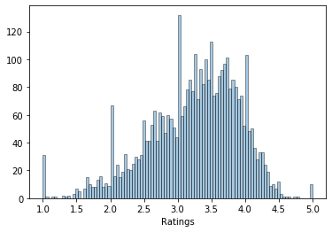

```python
sns.distplot(ratings['Ratings'], hist=True, kde=False, bins=100, hist_kws={'edgecolor':'#000000'})
```

We can see that most of the movies are rated between 2.5 and 4.

## 5.3 Plotting a Histogram to visualize the distribution of the Number of ratings with respect to movies

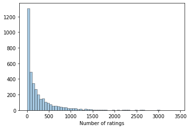

```python
sns.distplot(ratings['Number of ratings'], hist=True, kde=False, bins=60, hist_kws={'edgecolor':'#000000'})
```

From the above histogram it is clear that most movies have few ratings. Movies with most ratings are those that are most famous.

## 5.4 Plotting relationship between the rating of a movie and the number of ratings.

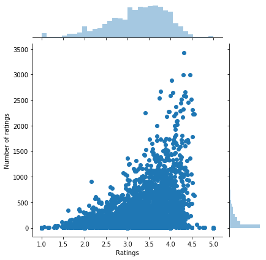

```python
import seaborn as sns
sns.jointplot(x='Ratings', y='Number of ratings', data=ratings)
```

From the diagram we can see that their is a positive relationship between the average rating of a movie and the number of ratings. The graph indicates that the more the ratings a movie gets the higher the average rating it gets. This is important to note especially when choosing the threshold for the number of ratings per movie.

# 6. Item based recommender system

Assume that a user has watched Air Force One (1997) and Contact (1997).

Our recommender system will recommend movies to this user based on this watching history.

The goal is to look for movies that are similar to Contact (1997) and Air Force One (1997) which our system will recommend to this user.

We can achieve this by computing the correlation between these two movies’ ratings and the ratings of the rest of the movies in the dataset.

## 6.1 Converting dataset into a matrix

Converting dataset into a matrix with the movie titles as the columns, the UserID as the index and the ratings as the values.

We will get output as dataframe with the columns as the movie titles and the rows as the user ids.

Each column represents all the ratings of a movie by all users.

The rating appear as NaN where a user didn't rate a certain movie.

Use of this matrix is to compute the correlation between the ratings of a single movie and the rest of the movies in the matrix.

```python
movie_matrix = Movie_Ratings.pivot_table(index='UserID', columns='MovieName', values='Ratings')
movie_matrix.head(5)
```

| MovieName UserID | $1,000,000 Duck (1971) | 'Night Mother (1986) | 'Til There Was You (1997) | 'burbs, The (1989) | ...And Justice for All (1979) | 1-900 (1994) | 10 Things I Hate About You (1999) | 101 Dalmatians (1961) | 101 Dalmatians (1996) | 12 Angry Men (1957) | ... | Young Poisoner's Handbook, The (1995) | Young Sherlock Holmes (1985) | Young and Innocent (1937) | Your Friends and Neighbors (1998) | Zachariah (1971) | Zed & Two Noughts, A (1985) | Zero Effect (1998) | Zero Kelvin (Kjærlighetens kjøtere) (1995) | Zeus and Roxanne (1997) | eXistenZ (1999) |
| --- | --- | --- | --- | --- | --- | --- | --- | --- | --- | --- | --- | --- | --- | --- | --- | --- | --- | --- | --- | --- | --- |
| 1 | NaN | NaN | NaN | NaN | NaN | NaN | NaN | NaN | NaN | NaN | ... | NaN | NaN | NaN | NaN | NaN | NaN | NaN | NaN | NaN | NaN |
| 2 | NaN | NaN | NaN | NaN | NaN | NaN | NaN | NaN | NaN | NaN | ... | NaN | NaN | NaN | NaN | NaN | NaN | NaN | NaN | NaN | NaN |
| 3 | NaN | NaN | NaN | NaN | NaN | NaN | NaN | NaN | NaN | NaN | ... | NaN | NaN | NaN | NaN | NaN | NaN | NaN | NaN | NaN | NaN |
| 4 | NaN | NaN | NaN | NaN | NaN | NaN | NaN | NaN | NaN | NaN | ... | NaN | NaN | NaN | NaN | NaN | NaN | NaN | NaN | NaN | NaN |
| 5 | NaN | NaN | NaN | NaN | NaN | NaN | NaN | NaN | NaN | NaN | ... | NaN | NaN | NaN | NaN | NaN | NaN | NaN | NaN | NaN | NaN |

5 rows × 3706 columns

## 6.2 Most rated movies

```python
ratings.sort_values('Number of ratings', ascending=False).head(10)
```

| MovieName | Ratings | Number of ratings |
| --- | --- | --- |
| American Beauty (1999) | 4.317386 | 3428 |
| Star Wars Episode IV - A New Hope (1977) | 4.453694 | 2991 |
| Star Wars Episode V - The Empire Strikes Back (1980) | 4.292977 | 2990 |
| Star Wars Episode VI - Return of the Jedi (1983) | 4.022893 | 2883 |
| Jurassic Park (1993) | 3.763847 | 2672 |
| Saving Private Ryan (1998) | 4.337354 | 2653 |
| Terminator 2 Judgment Day (1991) | 4.058513 | 2649 |
| Matrix, The (1999) | 4.315830 | 2590 |
| Back to the Future (1985) | 3.990321 | 2583 |
| Silence of the Lambs, The (1991) | 4.351823 | 2578 |

## 6.3 Implementing Correlation

```python
AFO_user_rating = movie_matrix['Air Force One (1997)']
contact_user_rating = movie_matrix['Contact (1997)']
```

We now have the dataframes showing the user_id and the rating they gave the two movies.

```python
AFO_user_rating.head()
contact_user_rating.head()
```

```
UserID
1   NaN
2   NaN
3   NaN
4   NaN
5   NaN
Name: Contact (1997), dtype: float64
```

In order to compute the correlation between two dataframes we use pandas corrwith functionality. Corrwith computes the pairwise correlation of rows or columns of two dataframe objects.

### 6.3.1 Correlation between each movie's rating and the ratings of the Air Force One movie.

```python
similar_to_air_force_one=movie_matrix.corrwith(AFO_user_rating)
similar_to_air_force_one.head(10)
```

```
MovieName
$1,000,000 Duck (1971)               0.529708
'Night Mother (1986)                 0.195627
'Til There Was You (1997)            0.238535
'burbs, The (1989)                   0.254954
...And Justice for All (1979)        0.092987
1-900 (1994)                              NaN
10 Things I Hate About You (1999)    0.114713
101 Dalmatians (1961)                0.285158
101 Dalmatians (1996)                0.367957
12 Angry Men (1957)                  0.037699
dtype: float64
```

### 6.3.2 Correlation between Contact (1997) ratings and the rest of the movies ratings.

```python
similar_to_contact = movie_matrix.corrwith(contact_user_rating)
similar_to_contact.head(10)
```

```
MovieName
$1,000,000 Duck (1971)              -0.119488
'Night Mother (1986)                 0.012834
'Til There Was You (1997)            0.205432
'burbs, The (1989)                   0.135900
...And Justice for All (1979)        0.269331
1-900 (1994)                              NaN
10 Things I Hate About You (1999)    0.065637
101 Dalmatians (1961)                0.073350
101 Dalmatians (1996)                0.232364
12 Angry Men (1957)                  0.199255
dtype: float64
```

## 6.4 Challenges

### 6.4.1 Dropping Null values

As our matrix has many missing values since not all the movies were rated by all the users.

We therefore drop those null values and transform correlation results into dataframes to make the results look more appealing.

```python
corr_contact = pd.DataFrame(similar_to_contact, columns=['Correlation'])
corr_contact.dropna(inplace=True)
corr_contact.head()
```

| MovieName | Correlation |
| --- | --- |
| $1,000,000 Duck (1971) | -0.119488 |
| 'Night Mother (1986) | 0.012834 |
| 'Til There Was You (1997) | 0.205432 |
| 'burbs, The (1989) | 0.135900 |
| ...And Justice for All (1979) | 0.269331 |

```python
corr_AFO = pd.DataFrame(similar_to_air_force_one, columns=['correlation'])
corr_AFO.dropna(inplace=True)
corr_AFO.head()
```

| MovieName | correlation |
| --- | --- |
| $1,000,000 Duck (1971) | 0.529708 |
| 'Night Mother (1986) | 0.195627 |
| 'Til There Was You (1997) | 0.238535 |
| 'burbs, The (1989) | 0.254954 |
| ...And Justice for All (1979) | 0.092987 |

### 6.4.2 Less Number of ratings

We have a challenge here that some of the movies have very few ratings and may end up being recommended simply because one or two people gave them a 5 star rating. We can fix this by setting a threshold for the number of ratings.

```python
corr_AFO = corr_AFO.join(ratings['Number of ratings'])
corr_contact = corr_contact.join(ratings['Number of ratings'])
corr_AFO.head()
corr_contact.head()
```

| MovieName | Correlation | Number of ratings |
| --- | --- | --- |
| $1,000,000 Duck (1971) | -0.119488 | 37 |
| 'Night Mother (1986) | 0.012834 | 70 |
| 'Til There Was You (1997) | 0.205432 | 52 |
| 'burbs, The (1989) | 0.135900 | 303 |
| ...And Justice for All (1979) | 0.269331 | 199 |

# 7. Recommendation output

## 7.1

Now our recommendor system gives the list of movies that are most similar to Air Force One (1997) by limiting them to movies that have at least 100 reviews. We then sort them by the correlation column and view the first 10.

```python
corr_AFO[corr_AFO['Number of ratings'] > 100].sort_values(by='correlation', ascending=False).head(10)
```

| MovieName | correlation | Number of ratings |
| --- | --- | --- |
| Air Force One (1997) | 1.000000 | 1076 |
| Major League Back to the Minors (1998) | 0.529945 | 142 |
| Monkey Shines (1988) | 0.525272 | 161 |
| Fear (1996) | 0.511704 | 128 |
| True Crime (1995) | 0.508214 | 135 |
| Next Best Thing, The (2000) | 0.500081 | 160 |
| Absolute Power (1997) | 0.498695 | 380 |
| Little Rascals, The (1994) | 0.497214 | 107 |
| Up Close and Personal (1996) | 0.481491 | 139 |
| Rosewood (1997) | 0.481477 | 126 |

We notice that Air Force One (1997) has a perfect correlation with itself, which is not surprising.

The next most similar movie to Air Force One (1997) is Major League Back to the Minors (1998) with a correlation of 0.529.

Limiting the number of rating gives us better results and we can confidently recommend the above movies to someone who has watched Air Force One (1997).

## 7.2

Applying same rule for Contact (1997) movie and check the movies that are most correlated to it.

```python
corr_contact[corr_contact['Number of ratings'] > 100].sort_values(by='Correlation', ascending=False).head(10)
```

| MovieName | Correlation | Number of ratings |
| --- | --- | --- |
| Contact (1997) | 1.000000 | 1382 |
| Girlfight (2000) | 0.585008 | 127 |
| Pollyanna (1960) | 0.495646 | 136 |
| Houseguest (1994) | 0.478564 | 138 |
| Nell (1994) | 0.476928 | 215 |
| Desperate Measures (1998) | 0.469439 | 111 |
| Swing Kids (1993) | 0.467377 | 185 |
| Big One, The (1997) | 0.457243 | 102 |
| Party Girl (1995) | 0.452346 | 105 |
| Missing in Action 2 The Beginning (1985) | 0.439398 | 104 |

The most similar movie to Contact (1997) is Girlfight (2000) with a correlation coefficient of 0.585 with 127 ratings.

So if somebody liked Contact (1997) we can recommend the above movies to them.

# Citations

https://www.kaggle.com

https://en.wikipedia.org/wiki

https://seaborn.pydata.org/

https://python-graph-gallery.com/